# COVID-19 Final Project

By Raghad, Amar, Majd

20/6/2021

### Part 1: Exploring the Covid concern dataset - `civiqs_poll.csv`.

First Let’s import the relevant libraries

```r
library(tidyverse)

library(lubridate)

library(scales)

library(tidymodels)

library(ggthemes)

library(tidyr)
```

Then Let’s import the data set and get to know it, we’ll do that by implementing the steps provided in the “Doing Data Science” presentation. Before formulating our questions let’s read into our data and understand its content.

```r
concern<-read_csv("data/civiqs_poll.csv")

glimpse(concern)
```

```
## Rows: 41
## Columns: 4
## $ date <chr> "2/25/2020", "2/26/2020", "2/27/2020", "2/28/2020", "2/29/2020", ~
## $ dem  <dbl> 35, 35, 35, 35, 36, 37, 37, 37, 38, 39, 39, 41, 43, 46, 49, 52, 5~
## $ rep  <dbl> -57, -58, -58, -58, -58, -58, -57, -56, -56, -56, -56, -56, -54, ~
## $ diff <dbl> 92, 93, 93, 93, 94, 95, 94, 93, 94, 95, 95, 97, 97, 97, 97, 96, 9~
```

```r
head(concern)
```

```
## # A tibble: 6 x 4
##   date        dem   rep  diff
##   <chr>     <dbl> <dbl> <dbl>
## 1 2/25/2020    35   -57    92
## 2 2/26/2020    35   -58    93
## 3 2/27/2020    35   -58    93
## 4 2/28/2020    35   -58    93
## 5 2/29/2020    36   -58    94
## 6 3/1/2020     37   -58    95
```

```r
tail(concern)
```

```
## # A tibble: 6 x 4
##   date        dem   rep  diff
##   <chr>     <dbl> <dbl> <dbl>
## 1 3/31/2020    79    15    64
## 2 4/1/2020     80    18    62
## 3 4/2/2020     80    19    61
## 4 4/3/2020     81    22    59
## 5 4/4/2020     81    22    59
## 6 4/5/2020     82    23    59
```

Looks like our data needs a bit of pre-processing.

As we can see, there’s `date` column of type ‘character’, for it to be useful in the analysis we’ll convert it to ‘date’ with the help of the `lubridate` package.

```r
#Note from observing the data, the date given is in the format month-day-year
concern<-concern%>%mutate(date=date%>%mdy())
glimpse(concern)
```

```
## Rows: 41
## Columns: 4
## $ date <date> 2020-02-25, 2020-02-26, 2020-02-27, 2020-02-28, 2020-02-29, 2020~
## $ dem  <dbl> 35, 35, 35, 35, 36, 37, 37, 37, 38, 39, 39, 41, 43, 46, 49, 52, 5~
## $ rep  <dbl> -57, -58, -58, -58, -58, -58, -57, -56, -56, -56, -56, -56, -54, ~
## $ diff <dbl> 92, 93, 93, 93, 94, 95, 94, 93, 94, 95, 95, 97, 97, 97, 97, 96, 9~
```

```r
#saveRDS(concern, file = "clean_data/concern.rds")
```

Now we’re good to continue, one more step before formulating our questions is the validation process, we validated the data with the provided source, the [Civiqs Polls Website](https://civiqs.com/results/coronavirus_concern?annotations=true&uncertainty=true&zoomIn=true&net=true), by checking the website and playing with the data. The website gave us essential information about the data, which will help us form our questions. Now we are sure and have a better understanding of it.

As stated in the source file, the dataset is the results of a poll about the Coronavirus Outbreak concern among the democratic party voters and the republican party voters in the US.

Knowing that this is our data, we will to use it to find out the following:

-How did each party voters react? were there party voters more concerned than the other party voters ?

Now let’s make the visualizations that help us answer these questions and see how individuals from both parties responded:

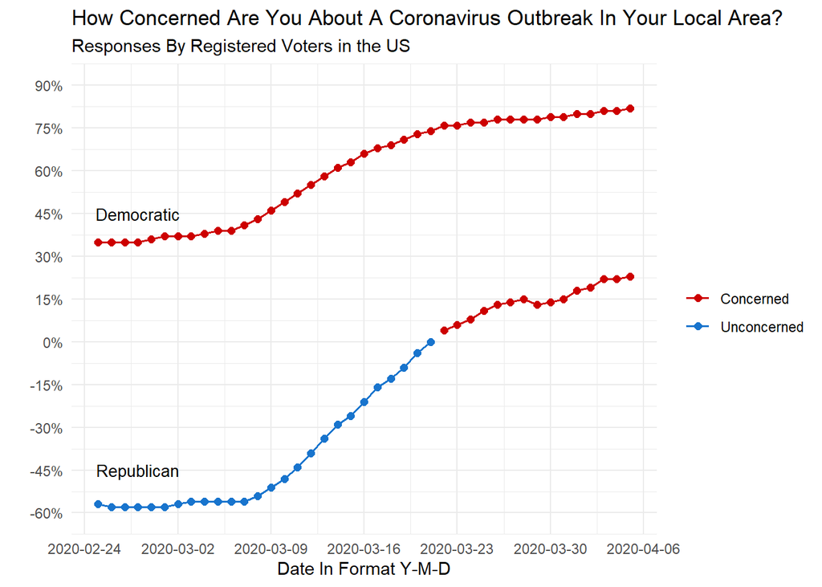

```r
#Plotting
concern_plot<- ggplot(concern, aes(x=date)) +

  geom_line(aes(y = dem, color=dem<0), size=0.7)+

  geom_point(aes(y = dem, color=dem<0), size=2)+

  geom_line(aes(y = rep, color=rep<=0), size=0.7) +

  geom_point(aes(y = rep, color=rep<=0), size=2)+

  scale_x_date(date_breaks = "1 week")+

  scale_y_continuous(labels= function(x) paste0(x, "%"),limits=c(-60, 90),breaks = seq(from = -60, to = 90, by = 15))+

  theme_minimal()+

  annotate("text", x=as.Date("2020-02-28"), y = -45, label = "Republican", size=3.5)+

  annotate("text", x=as.Date("2020-02-28"), y = 45, label = "Democratic", size=3.5)+

  scale_color_manual(labels=c("Concerned", "Unconcerned"), values =c("red3", "dodgerblue3"))+

  labs(title="How Concerned Are You About A Coronavirus Outbreak In Your Local Area?", subtitle = "Responses By Registered Voters in the US", x="Date In Format Y-M-D", y="", color="" )

concern_plot
```

It is very clear that there’s a gap in the responses between the two parties, democrats are obviously more concerned than the republicans, however, the unconcern among republicans is gradually reduced as time passes, and we note that starting from a certain date the unconcern among republicans is significantly decreasing, along with it the concern among democrats increases. To further understand this phenomenon and the behavior of the lines we’ll add events to the plot.

```r
#Creating events dataframe to help us add them to the plot
events_df <- data.frame(matrix(ncol = 2, nrow = 0))

#Adding 2 events to the df
events_df <-rbind(events_df, c("2020-03-21", "WH projects\n100-240k\ndeaths"))
events_df <-rbind(events_df, c("2020-03-13", "National\nemergency\ndeclared"))

#Naming the columns
names(events_df) <- c("date", "event")

#Converting the date column from `character` to `date`
events_df<-events_df%>%mutate(date=date%>%ymd())
events_df
```

```
##         date                         event
## 1 2020-03-21 WH projects\n100-240k\ndeaths
## 2 2020-03-13 National\nemergency\ndeclared
```

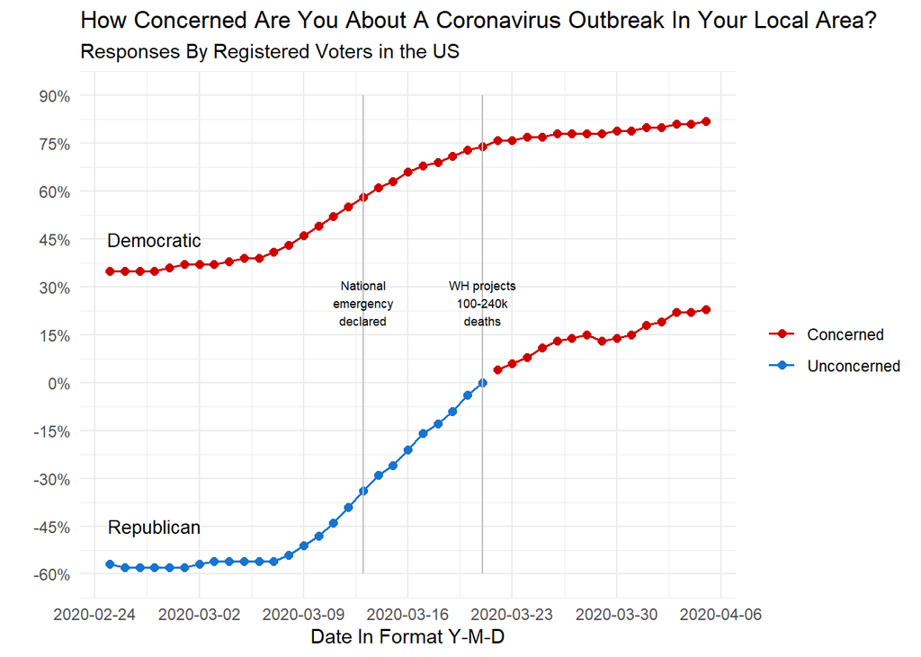

```r
#Adding the events to the previous graph - concern_plot
concern_plot +

   geom_segment(data = events_df, aes(x = date, y = 90, xend = date, yend =-60), color = "grey") +

  geom_text(data = events_df , aes(x = date, y =  25, label = event), color = "black", size=2.4)
```

## Exploring the Covid cases dataset

After Exploring the Covid Concern dataset, now we’ll explore the Covid Cases, its data is taken from [Wikipedia](https://en.wikipedia.org/wiki/Template:COVID-19_pandemic_data/United_States_medical_cases), so first we have to scrape it, clean it and tidy it, the entire process of scraping, splitting, pivoting, cleaning, tidying the data is in the R script file in this Project:

For a more comfortable analysis, we split the scraped_data into two dataframes, cases1 and cases2, the explanation on how we did this is included in the R script file as code comments. Now, we’ll load the clean data and explore it:

```r
cases1 <- readRDS("~/Project/clean_data/cases1.rds")
cases2 <- readRDS("~/Project/clean_data/cases2.rds")
```

First look:

```r
glimpse(cases1)
```

```
## Rows: 26,400
## Columns: 4
## $ Date   <date> 2020-01-21, 2020-01-21, 2020-01-21, 2020-01-21, 2020-01-21, 20~
## $ State  <chr> "AK", "AZ", "CA", "CO", "HI", "ID", "MT", "NM", "NV", "OR", "UT~
## $ Region <chr> "West", "West", "West", "West", "West", "West", "West", "West",~
## $ Cases  <dbl> 0, 0, 0, 0, 0, 0, 0, 0, 0, 0, 0, 1, 0, 0, 0, 0, 0, 0, 0, 0, 0, ~
```

```r
#This is the second split of the scraped_data df, which contains summery of daily cases in all the states and regions
glimpse(cases2)
```

```
## Rows: 480
## Columns: 8
## $ Date            <date> 2020-01-21, 2020-01-24, 2020-01-25, 2020-01-26, 2020-~
## $ Daily_Confirmed <int> 1, 1, 1, 2, 1, 1, 1, 3, 1, 0, 2, 0, 1, 0, 4, 5, 18, 15~
## $ Total_Confirmed <int> 1, 2, 3, 5, 6, 7, 8, 11, 12, 12, 14, 14, 15, 15, 19, 2~
## $ Daily_Deaths    <int> 0, 0, 0, 0, 0, 0, 0, 0, 0, 0, 0, 0, 0, 0, 0, 1, 1, 4, ~
## $ Total_Deaths    <int> 0, 0, 0, 0, 0, 0, 0, 0, 0, 0, 0, 0, 0, 0, 0, 1, 2, 6, ~
## $ Daily_Recovered <int> 0, 0, 0, 0, 0, 0, 0, 0, 0, 3, 2, 1, 0, 0, 0, 1, 2, 0, ~
## $ Total_Recovered <int> 0, 0, 0, 0, 0, 0, 0, 0, 0, 3, 5, 6, 6, 6, 6, 7, 9, 9, ~
## $ Total_Active    <int> 1, 2, 3, 5, 6, 7, 8, 11, 12, 9, 9, 8, 9, 9, 13, 16, 31~
```

Let’s check out some simple visualizations first to get a larger idea on the data and the numbers

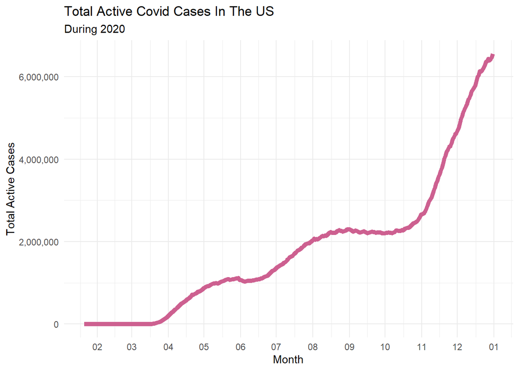

```r
#Simple Plot 1
#For our analysis we're interested in 2020 data only
smpl_plots<-cases2%>%filter(between(Date,ymd("2020-01-21"),ymd("2020-12-31")))


#Plotting
ggplot(smpl_plots,aes(Date,Total_Active))+

  geom_line(color="hotpink3", size=2)+

  labs(title="Total Active Covid Cases In The US", subtitle = "During 2020", x="Month", y="Total Active Cases")+

   scale_y_continuous(labels= scales::comma)+

   scale_x_date(date_breaks = "1 month", date_labels = "%m")+

  theme_minimal()
```

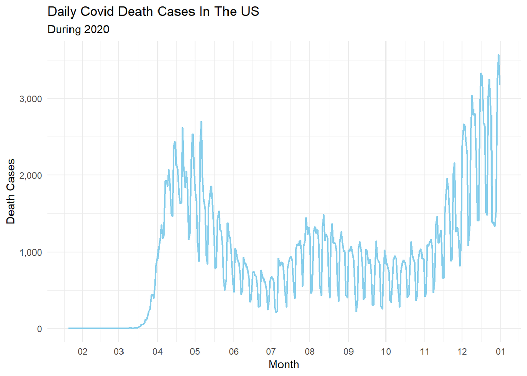

```r
#Simple Plot 2
#For our analysis we're interested in 2020 data only

#Plotting
ggplot(smpl_plots,aes(Date,Daily_Deaths))+

  geom_line(color="skyblue", size=0.75)+

  labs(title="Daily Covid Death Cases In The US", subtitle = "During 2020", x="Month", y="Death Cases")+

   scale_y_continuous(labels= scales::comma)+

   scale_x_date(date_breaks = "1 month", date_labels = "%m")+

  theme_minimal()
```

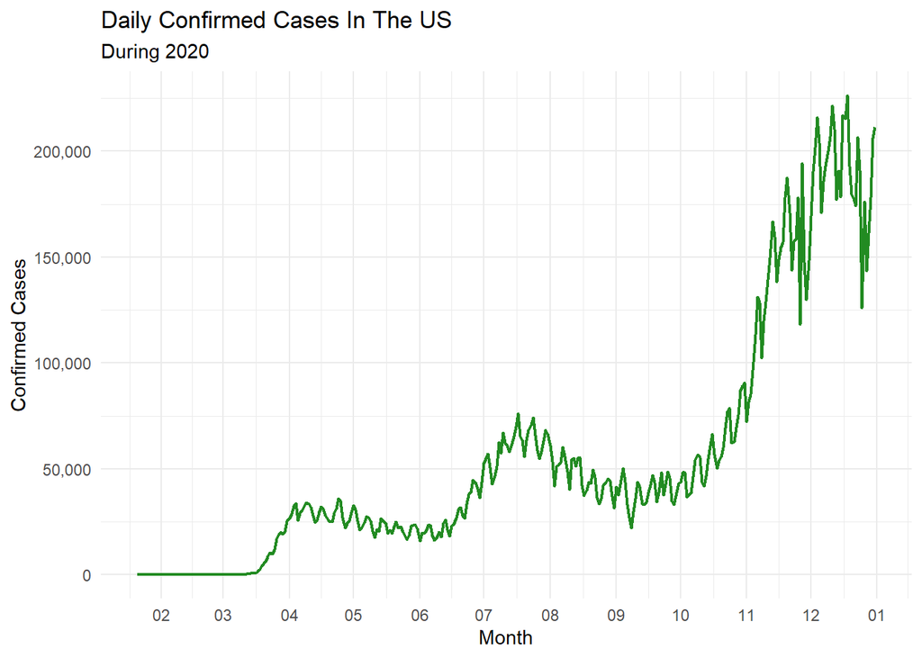

```r
#Simple Plot 3
#For our analysis we're interested in 2020 data only

#Plotting
ggplot(smpl_plots,aes(Date,Daily_Confirmed))+

  geom_line(color="forestgreen", size=0.75)+

  labs(title="Daily Confirmed Cases In The US", subtitle = "During 2020", x="Month", y="Confirmed Cases")+

   scale_y_continuous(labels= scales::comma)+

   scale_x_date(date_breaks = "1 month", date_labels = "%m")+

  theme_minimal()
```

Now we Have an idea on the numbers we’re dealing with.

Let’s check out the cases in the year 2020 by each month in every region, and see the numbers in each region, we’ll exclude the Territories of the US because it’s irrelevant in our analysis, also it would be more convenient here to normalize the data, meaning, we will divide the number of cases by the population in each region, so we can compare the situation between all regions, the 2020 population data we’ll take from [here](https://en.wikipedia.org/wiki/List_of_states_and_territories_of_the_United_States_by_population).

```r
#Creating a df for the plotting
#Counting the cases by the month and region
monthly_cases<-cases1%>%

  filter(between(Date,ymd("2020-01-21"),ymd("2020-12-30")), Region!="Territories")%>%

  group_by(Month=month(Date), Region)%>%

  summarise(Total_cases=sum(Cases))

#Check the result
head(monthly_cases)
```

```
## # A tibble: 6 x 3
## # Groups:   Month [2]
##   Month Region    Total_cases
##   <dbl> <chr>           <dbl>
## 1     1 Midwest             2
## 2     1 Northeast           0
## 3     1 South               0
## 4     1 West                5
## 5     2 Midwest             2
## 6     2 Northeast           1
```

```r
#Creating a df to help us in the plot
#Population in every region
Region<-c("West", "South","Northeast", "Midwest" )

Population_2020<-c(78588572, 126266107, 57609148, 68985454)

population<-data.frame(Region, Population_2020)

#Joining the helping dfs for the plot
pop_cases<-left_join(monthly_cases, population)

#Check the result
head(pop_cases)
```

```
## # A tibble: 6 x 4
## # Groups:   Month [2]
##   Month Region    Total_cases Population_2020
##   <dbl> <chr>           <dbl>           <dbl>
## 1     1 Midwest             2        68985454
## 2     1 Northeast           0        57609148
## 3     1 South               0       126266107
## 4     1 West                5        78588572
## 5     2 Midwest             2        68985454
## 6     2 Northeast           1        57609148
```

```r
#Adding a column for the portion of cases in the population
pop_cases<-pop_cases%>%mutate(Portion=Total_cases/Population_2020)
head(pop_cases)
```

```
## # A tibble: 6 x 5
## # Groups:   Month [2]
##   Month Region    Total_cases Population_2020      Portion
##   <dbl> <chr>           <dbl>           <dbl>        <dbl>
## 1     1 Midwest             2        68985454 0.0000000290
## 2     1 Northeast           0        57609148 0
## 3     1 South               0       126266107 0
## 4     1 West                5        78588572 0.0000000636
## 5     2 Midwest             2        68985454 0.0000000290
## 6     2 Northeast           1        57609148 0.0000000174
```

```r
#Check the result
head(pop_cases)
```

```
## # A tibble: 6 x 5
## # Groups:   Month [2]
##   Month Region    Total_cases Population_2020      Portion
##   <dbl> <chr>           <dbl>           <dbl>        <dbl>
## 1     1 Midwest             2        68985454 0.0000000290
## 2     1 Northeast           0        57609148 0
## 3     1 South               0       126266107 0
## 4     1 West                5        78588572 0.0000000636
## 5     2 Midwest             2        68985454 0.0000000290
## 6     2 Northeast           1        57609148 0.0000000174
```

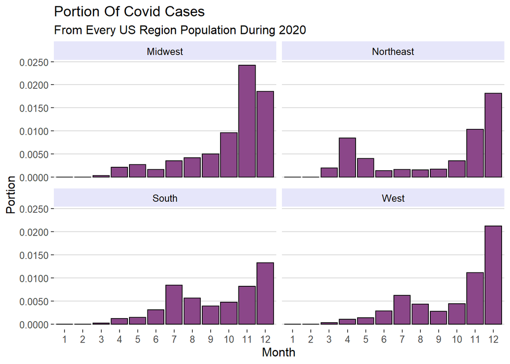

```r
#Plotting
ggplot(data=pop_cases, aes(x=factor(Month), y=Portion))+

  geom_histogram(stat="identity", color="black", fill="orchid4")+

  scale_y_continuous(labels= scales::comma)+

  scale_x_discrete()+

  facet_wrap(~Region, nrow(3), ncol(3))+

  labs(title="Portion Of Covid Cases ",
       subtitle = "From Every US Region Population During 2020", y="Portion", x="Month")+

   theme_bw()+

   theme(strip.background =element_rect(fill="lavender"))+

   theme(strip.text = element_text(colour = 'black'))+

   theme_hc()+

   scale_colour_hc()
```

let’s try to find connection between the concern dataset and the cases dataset, for us to do so, we need additional data, because the concern dataset consists of only 2 columns and they’re in the realm of American politics, so we need to bring some political data to the cases dataframe in order to be able to explore them together.

Is It really that Republicans are less concerned and have more cases? Is It really that Democrats are more concerned and have less cases?

Can the cases dataset give us additional explanations to the rise in concern for both parties?

```r
Election1 <- readRDS("~/Project/clean_data/Election1.rds")
#Let's join the two datasets
party_cases<-inner_join(cases1, Election1)
#Now let's group the states by the winnig party
#for us to be able to find a connection with the consern dataset
glimpse(party_cases)
```

```
## Rows: 24,480
## Columns: 7
## $ Date            <date> 2020-01-21, 2020-01-21, 2020-01-21, 2020-01-21, 2020-~
## $ State           <chr> "AK", "AZ", "CA", "CO", "HI", "ID", "MT", "NM", "NV", ~
## $ Region          <chr> "West", "West", "West", "West", "West", "West", "West"~
## $ Cases           <dbl> 0, 0, 0, 0, 0, 0, 0, 0, 0, 0, 0, 1, 0, 0, 0, 0, 0, 0, ~
## $ STATE           <chr> "Alaska", "Arizona", "California", "Colorado", "Hawaii~
## $ ELECTORAL.VOTES <int> 3, 11, 55, 9, 4, 4, 3, 5, 6, 7, 6, 12, 3, 6, 20, 11, 6~
## $ WINNER          <chr> "Trump", "Trump", "Clinton", "Clinton", "Clinton", "Tr~
```

```r
prty_date_cases<-party_cases%>%group_by(Date, WINNER)%>%summarise(Cases=sum(Cases))
#check the result
head(prty_date_cases)
```

```
## # A tibble: 6 x 3
## # Groups:   Date [3]
##   Date       WINNER  Cases
##   <date>     <chr>   <dbl>
## 1 2020-01-21 Clinton     1
## 2 2020-01-21 Trump       0
## 3 2020-01-24 Clinton     1
## 4 2020-01-24 Trump       0
## 5 2020-01-25 Clinton     1
## 6 2020-01-25 Trump       0
```

```r
#Trying to fix stubborn error that comes up in the joining
concern<-concern%>%mutate(Date_numeric=as.numeric(as.Date(concern$date)))

#prty_date_cases<-prty_date_cases%>%mutate(Date_numeric=as.numeric(prty_date_cases$Date))

#Now that we have the relevant data we can combine it with the concern dataset

#Weired stubborn error and the internet wasnt helpful :(
#concern_cases<-inner_join(prty_date_cases, concern, by=c("Date_numeric", "Date_numeric"))

#Check the result
#head(concern_cases)

#data for seperate plots for each party
#dem_party<-concern_cases%>%filter(WINNER=="Clinton")
#head(dem_party)
#rep_party<-concern_cases%>%filter(WINNER=="Trump")

#ggplot(dem_party, aes(Date, Cases))+
  #geom_point(aes(alpha=dem))
```

```r
#libraries for plotting map
library(maps)
library(usdata)
us_states <- map_data("state")

#This data will help us plot the map
#let's check it
head(us_states)
```

```
##        long      lat group order  region subregion
## 1 -87.46201 30.38968     1     1 alabama      <NA>
## 2 -87.48493 30.37249     1     2 alabama      <NA>
## 3 -87.52503 30.37249     1     3 alabama      <NA>
## 4 -87.53076 30.33239     1     4 alabama      <NA>
## 5 -87.57087 30.32665     1     5 alabama      <NA>
## 6 -87.58806 30.32665     1     6 alabama      <NA>
```

```r
#the region column here is the state, let's be consistent and rename it
names(us_states)[names(us_states) == "region"] <- "State"

#This df contains the state and the region it belongs to
#excluding the territories because they're irrelevant in our analysis
state_region<-cases1%>%
  select(State, Region)%>%
  filter(Region!="Territories")

state_region<-unique(state_region[c("State", "Region")])

glimpse(state_region)
```

```
## Rows: 51
## Columns: 2
## $ State  <chr> "AK", "AZ", "CA", "CO", "HI", "ID", "MT", "NM", "NV", "OR", "UT~
## $ Region <chr> "West", "West", "West", "West", "West", "West", "West", "West",~
```

```r
#Converting the abbreviation to the full state name and creating a new
#column for it
state_region<-state_region%>%mutate(STATE=abbr2state(state_region$State))

#turning the states name to lower case to use them in joining
state_region$STATE <- tolower(state_region$STATE)

#check the data
glimpse(state_region)
```

```
## Rows: 51
## Columns: 3
## $ State  <chr> "AK", "AZ", "CA", "CO", "HI", "ID", "MT", "NM", "NV", "OR", "UT~
## $ Region <chr> "West", "West", "West", "West", "West", "West", "West", "West",~
## $ STATE  <chr> "alaska", "arizona", "california", "colorado", "hawaii", "idaho~
```

```r
#we'll combine the two dfs above by the state
us_plot_data<-inner_join(us_states,state_region, by = c("State" = "STATE"))

#Now we'll combine it with the cases
merge(us_plot_data, cases1)
```

```
##  [1] State     Region    long      lat       group     order     subregion
##  [8] State.y   Date      Cases
## <0 rows> (or 0-length row.names)
```

```r
glimpse(us_plot_data)
```

```
## Rows: 15,537
## Columns: 8
## $ long      <dbl> -87.46201, -87.48493, -87.52503, -87.53076, -87.57087, -87.5~
## $ lat       <dbl> 30.38968, 30.37249, 30.37249, 30.33239, 30.32665, 30.32665, ~
## $ group     <dbl> 1, 1, 1, 1, 1, 1, 1, 1, 1, 1, 1, 1, 1, 1, 1, 1, 1, 1, 1, 1, ~
## $ order     <int> 1, 2, 3, 4, 5, 6, 7, 8, 9, 10, 11, 12, 13, 14, 15, 16, 17, 1~
## $ State     <chr> "alabama", "alabama", "alabama", "alabama", "alabama", "alab~
## $ subregion <chr> NA, NA, NA, NA, NA, NA, NA, NA, NA, NA, NA, NA, NA, NA, NA, ~
## $ State.y   <chr> "AL", "AL", "AL", "AL", "AL", "AL", "AL", "AL", "AL", "AL", ~
## $ Region    <chr> "South", "South", "South", "South", "South", "South", "South~
```

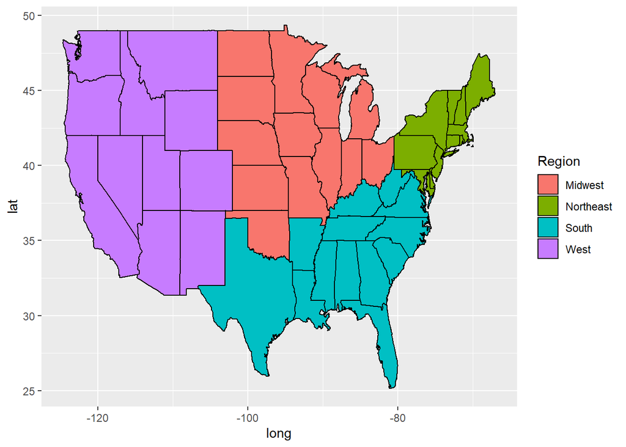

```r
p <- ggplot(data = us_plot_data,
            mapping = aes(x = long, y = lat,
                          group = group, fill=Region, color=State))

p + geom_polygon(color = "black")
```

## Part 2:

```r
### importing required librarys
library(tidyverse)
library(tidytext)
library(tidymodels)
library(textrecipes)
library(glue)
library(robotstxt)
library(rvest)
library(magrittr)
library(lubridate)
```

```r
 ### covid concern dataset
concern<- concern %>%
  rename_with(str_to_title) # making a title name for all columns

head(concern)
```

```
## # A tibble: 6 x 5
##   Date         Dem   Rep  Diff Date_numeric
##   <date>     <dbl> <dbl> <dbl>        <dbl>
## 1 2020-02-25    35   -57    92        18317
## 2 2020-02-26    35   -58    93        18318
## 3 2020-02-27    35   -58    93        18319
## 4 2020-02-28    35   -58    93        18320
## 5 2020-02-29    36   -58    94        18321
## 6 2020-03-01    37   -58    95        18322
```

```r
### trump tweets dataset
trump <- readRDS("~/Project/clean_data/trump.rds")

#Tidying the date column, separating date and time
#and creating an individual column for each
#converting the date from `character` to `date`
trump <-separate(trump, date, c("Date", "Time"), sep = " ") %>%
  mutate(Date=as.Date(Date))


#Preparing the regrex expressions for the data cleaning
rgrs_symbols <- "@\\w+|https?://.+|\\d+\\w*\\d*|#\\w+|[^\x01-\x7F]|[[:punct:]]|rt|"

rgrs_spaces <- "\n|^\\s+|\\s+$|[ |\t]+"

replace_rgrs <- paste(rgrs_symbols,rgrs_spaces,collapse = NULL)

#Converting the text to small letter for the analysis
#Cleaning the data of spaces, new lines, mentions, unnecessary characters.. using regrex expressions
#Using a unified name for the Covid 19 and all its various spellings
trump_clean_text <- trump %>%

  mutate(text=tolower(text)) %>%

  mutate(text = str_replace_all(text, replace_rgrs, " "))%>%

  mutate(
    text = str_replace_all(text, "COVID-19", "COVID_19"),
    text = str_replace_all(text, "COVID 19", "COVID_19"),
    text = str_replace_all(text, "Covid-19", "COVID_19"),
    text = str_replace_all(text, "Covid 19", "COVID_19")
  )


head(trump_clean_text)
```

```
##         Date     Time favorites                  id isRetweet retweets
## 1 2020-04-04 16:48:47         0 1246434545357987842      TRUE     4410
## 2 2020-04-04 16:48:32     74661 1246434478744047616     FALSE    10449
## 3 2020-04-04 16:47:22         0 1246434186942128129      TRUE     3063
## 4 2020-04-04 16:46:39         0 1246434007258144768      TRUE     3321
## 5 2020-04-04 16:46:31         0 1246433974869798913      TRUE     2500
## 6 2020-04-04 16:45:39         0 1246433754161217536      TRUE   108116
##                                                                                                                             text
## 1                great reconnecting with president kaljulaid of estonia  her leadership and innovativeness is truly admirable
## 2                                                                                                               i fully agree
## 3
## 4      i couldn t agree more  our national parks are national treasures  this legislation will ensure they are preserved and pr
## 5                                  proud co sponsor of this impo ant conservation legislation that helps keep west virginia
## 6                                                                                               the united states loves italy
```

```r
# making tokens from the tweet text column
#2gram tokenize
#dropping stopwords - unusful for our analysis
tokenized_trump<-trump_clean_text %>%

  unnest_tokens(word, text, token = "ngrams", n = 2, n_min = 1) %>%

  anti_join(stop_words, by = "word")

head(tokenized_trump)
```

```
##         Date     Time favorites                  id isRetweet retweets
## 1 2020-04-04 16:48:47         0 1246434545357987842      TRUE     4410
## 2 2020-04-04 16:48:47         0 1246434545357987842      TRUE     4410
## 3 2020-04-04 16:48:47         0 1246434545357987842      TRUE     4410
## 4 2020-04-04 16:48:47         0 1246434545357987842      TRUE     4410
## 5 2020-04-04 16:48:47         0 1246434545357987842      TRUE     4410
## 6 2020-04-04 16:48:47         0 1246434545357987842      TRUE     4410
##                  word
## 1  great reconnecting
## 2        reconnecting
## 3   reconnecting with
## 4      with president
## 5           president
## 6 president kaljulaid
```

```r
## plots and summarise for the tweet text dataset after (text analysis)
# taking sample from trump ngrams
trump_ngrams <- tokenized_trump %>%
  group_by(Date,word) %>%
  summarise(n = n(), .groups = "drop") %>% # word frequency
  arrange(desc(n)) %>% # arrange the words frequency in decending order
  rowid_to_column(var = "index") %>% # adding index column
  filter(word!='trump') %>% # no need for the word trump
  filter(index<=5000) # sample of the dataset

head(trump_ngrams)
```

```
## # A tibble: 6 x 4
##   index Date       word            n
##   <int> <date>     <chr>       <int>
## 1     1 2020-03-20 coronavirus    34
## 2     2 2020-03-20 senate         26
## 3     3 2020-03-22 businesses     24
## 4     4 2020-03-22 coronavirus    20
## 5     5 2020-03-29 with the       20
## 6     6 2020-03-20 in the         18
```

```r
# adding the sentiment column for the dataset
trump_bing_word_count<-trump_ngrams %>%
  inner_join(get_sentiments("bing"), by = "word") %>%
  arrange(index)
head(trump_bing_word_count)
```

```
## # A tibble: 6 x 5
##   index Date       word       n sentiment
##   <int> <date>     <chr>  <int> <chr>
## 1    14 2020-03-28 fake      16 negative
## 2    23 2020-03-20 relief    14 positive
## 3    53 2020-03-02 strong    11 positive
## 4   104 2020-03-20 sick       8 negative
## 5   111 2020-03-22 relief     8 positive
## 6   123 2020-03-23 virus      8 negative
```

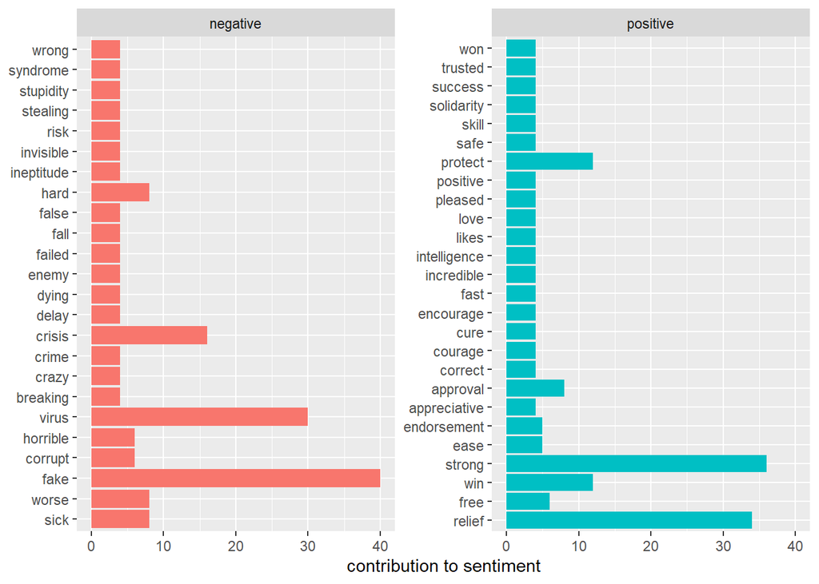

```r
# plot showing the the word frequency with partition of sentiment
trump_bing_word_count %>%
  group_by(sentiment) %>%
  slice_max(n,n=10) %>%
  ungroup() %>%
  mutate(word=reorder(word, n)) %>%
  ggplot(aes(n,reorder(word,-n),fill=sentiment),stat="identity") +
  geom_col(show.legend=FALSE) +
  facet_wrap(~sentiment,scales="free_y") +
  labs(x="contribution to sentiment", y=NULL)
```